# Ranks probability and weights

Mohamad Shakil Hasan

16 July 2017

#### Package version: OPWpaper 0.99.1

# Contents

Below we generate the necessary plots to demonstrate the ranks probability and the corresponding normalized weight for the different effect sizes and the proportion of the true nulls.

Load the necessary libraries

```r
library(OPWpaper)
library(ggplot2)
library(reshape2)       # library for the melt function
library(cowplot)        # plot_grid function
```

# 1 Ranks probability and weights

Load the data stored in *OPWpaper*

```r
ranksProb <- read.csv(system.file("simulations/results/ranksProb_byEffect_m10000.csv",
                         package = "OPWpaper"), h = TRUE)
ranksWeight_cont <- read.csv(system.file("simulations/results/Weight_byEffect_cont_m10000.csv",
                         package = "OPWpaper"), h = TRUE)
```

The following Figures show the ranks probabilities, $P(r_i=k \mid E(\varepsilon_i))$, and the corresponding normalized weights, $w_i$, versus ranks, where the mean covariate effect size $E(\varepsilon_i)$ refers to $ey$. For each figure, the first column is for the different proportion of the true null hypothesis when the mean test-effect ($et$) and the mean covariate-effect ($ey$) are the same ($2$ or $1$), and the second column is for the different mean effect sizes when the proportion of the true null tests is $50\%$ or $90\%$. To generate this plot, we applied the proposed normal approximation method. We assumed that there are $m = 10,000$ hypotheses tests; the test statistics follow the normal distributions with mean $0$ and $\varepsilon_i$ under the null and the alternative hypothesis, respectively, and standard deviations $1$.

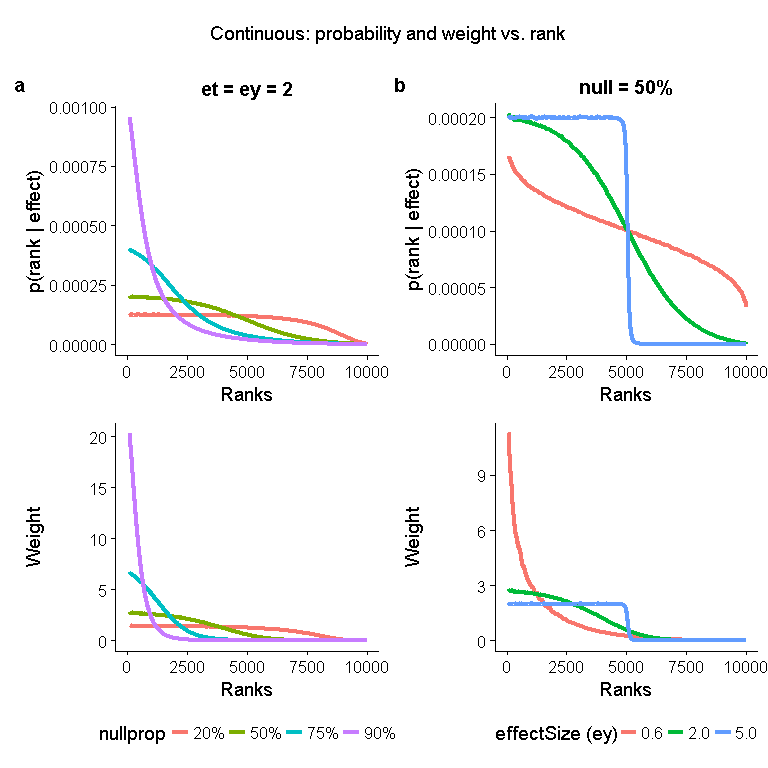

```r
prob_weight_plots(ey_index = c(7, 17, 27, 37), null_index = c(14, 17, 19),
                                m = 10000, ey = 2, null = 50, prob = ranksProb,
                                weight = ranksWeight_cont)
```

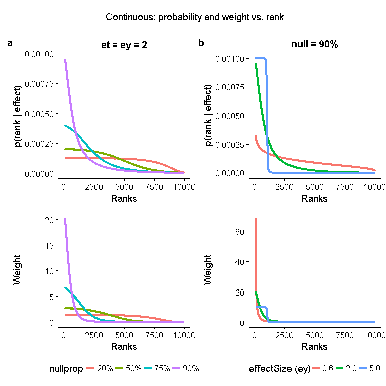

```r
prob_weight_plots(ey_index = c(7, 17, 27, 37), null_index = c(34, 37, 39),
                                m = 10000, ey = 2, null = 90, prob = ranksProb,
                                weight = ranksWeight_cont)
```

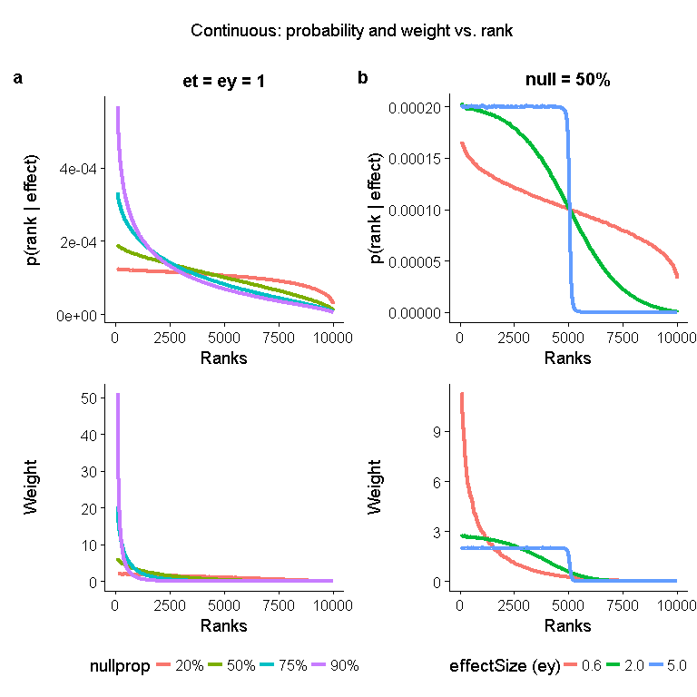

```r
prob_weight_plots(ey_index = c(6, 16, 26, 36), null_index = c(14, 17, 19),
                                m = 10000, ey = 1, null = 50, prob = ranksProb,
                                weight = ranksWeight_cont)
```

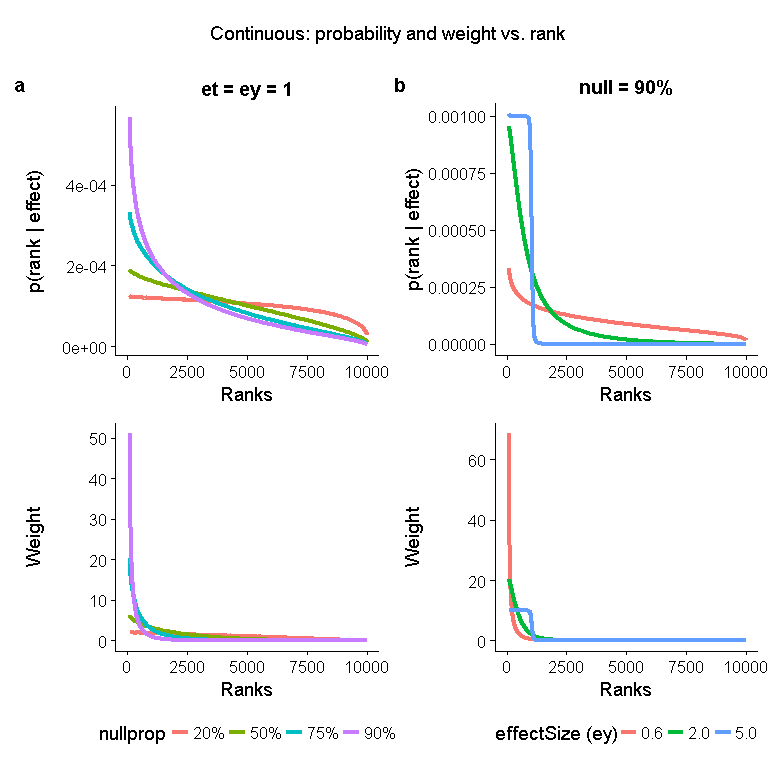

```r
prob_weight_plots(ey_index = c(6, 16, 26, 36), null_index = c(34, 37, 39),
                                m = 10000, ey = 1, null = 90, prob = ranksProb,
                                weight = ranksWeight_cont)
```